# Ford GoBike User Type Analysis

## by Justin Foster

## Investigation Overview

I have looked for details regarding the Ford GoBike user types general information. In the next few slides, I will present breakdowns showing the composition of the entire user base first. These will consist of the entire user base's user type division and gender division respectively. I will then build upon those base line metrics by presenting gender composition for both the Customer user type and the Subscriber user type separately. Finally, I will end the presentation by further building on top of the previous breakdowns with to highlight average user age in years and trip time in minutes for each gender in the Customer and Subscriber user types.

## Dataset Overview

This data set includes information about individual rides made in a bike-sharing system covering the greater San Francisco Bay area called "Ford GoBike". Ford Gobike was created by the Ford motor company in partnership with the company "Motivate" and introduced to the San Fransisco Bay Area in 2017. The goal of the system is to help reduce traffic congestion in the city by providing an alternative mode of transportation. More information on this system can be located on Ford's media website [HERE](https://media.ford.com/content/fordmedia/fna/us/en/news/2017/06/27/ford-gobike-launching-in-bay-area-bike-sharing.html).

## (Types of Users Across All Trips

Below is a breakdown of user types across the full user base. We can see that across all trips available in the data set; 91% of the trips were taken by Subscriber users and 9% of the trips were taken by Customer users.

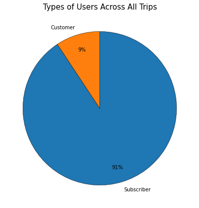

## Gender of Users Across All Trips

Below is a breakdown of gender across the full user base. We can see that across all trips available in the data set; 75% of the trips were taken by male users, 23% of trips were taken by female users, and 2% of trips were taken by users of other genders.

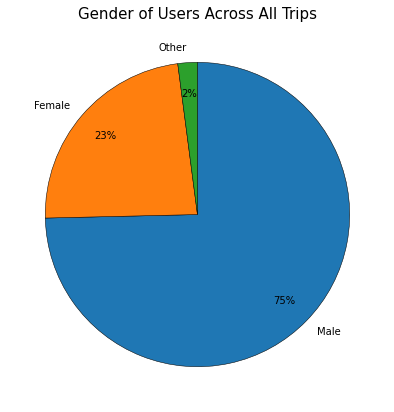

## User Type by Gender Composition

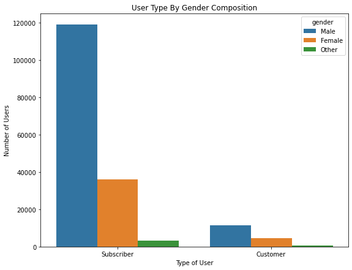

## Average Trip Time for Each User Type by Gender

Below we begin comparing the different user types, seperated by genders, based on average number of minutes they take per trip. It is interesting to note that even though many more trips were taken by Subscriber users, it appears they have a lower average trip time in minutes in every gender category as opposed to the trips taken by Customer users.

**Customers (least to most):**

- Other: About 14.7 minutes.
- Male: About 15 minutes.
- Female: About 17 minutes.

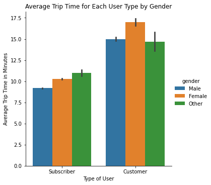

## Average Age for Each User Type by Gender

Below we end the presentation by comparing the different user types, seperated by genders, based on their average age in years. It is interesting to note that even though Subscribers and Customers take a largerly different amount of trips, their average ages across genders is nearly identical.

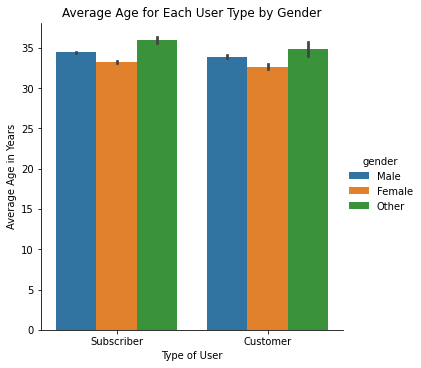